# Actuarial Exams Analysis

## 16 1 6 1 1

make_network = function(cur_data, cur_size = 10, add.label = T){

#Due to a restriction on RcolorBrewer, we can only use a max of 9 genres.

#Here I filter out all but the 9 most popular. I do so only when necessary

if( length(unique( cur_data$genres_simple)) > 9) {

cur_data = filter( cur_data, ( genres_simple %in% c("Action",

"Adventure",

"Animation",

"Comedy",

"Crime",

"Drama",

"Fantasy",

"Horror",

4

[figure not shown]

"Biography")))

}

n = nrow(cur_data)

#Need an index number for each link to match

vectorize = function(input_links){

out = c(rep(0, n))

for(i in input_links){

index = match(i, cur_data$links)

out[index] = 1

}

return(out)

}

each_links = sapply(cur_data$links, get_links)

links_matrix = ldply(each_links, vectorize) %>%

select(-1) %>%

as.matrix()

#Add movie titles

rownames(links_matrix) = cur_data$title

colnames(links_matrix) = cur_data$title

#Remove empty connections, ie, movies with no links

# links_matrix = links_matrix[,which(!apply(links_matrix,2,FUN = function(x){all(x == 0)}))]

# links_matrix = links_matrix[which(!apply(links_matrix,2,FUN = function(x){all(x == 0)})), ]

#

net1 = network( links_matrix, directed = F, na.rm = F)

# cur_data = filter(cur_data, (title %in% rownames(links_matrix)))

network.vertex.names(net1) = rownames(links_matrix)

length = nrow(links_matrix)

ggnet2(net1,

color = cur_data$genres_simple,

palette = "Set1",

label = add.label,

size = cur_size)

}

Movies in the US released after 2016

You can ﬁnd interesting patterns between the linked movies over diﬀerent years.

make_network(mydata)

## Loading required package: scales

5

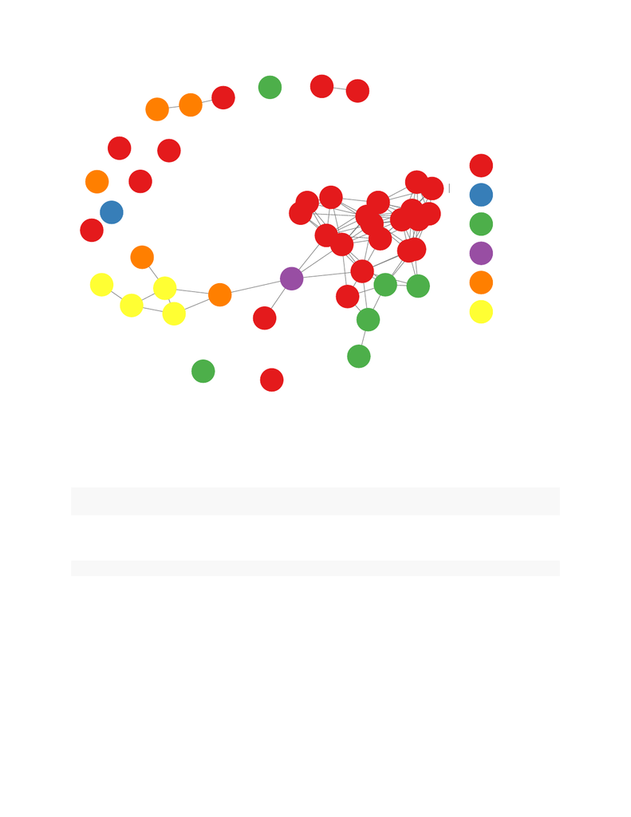

Batman v Superman: Dawn of Justice

Captain America: Civil War

Star Trek Beyond

The Legend of Tarzan

X−Men: Apocalypse

Suicide Squad

Independence Day: Resurgence

Alice Through the Looking Glass

Warcraft

The Legend of Tarzan

Ghostbusters

Kung Fu Panda 3

Gods of Egypt

The Huntsman: Winter's War

Allegiant

Now You See Me 2

The Angry Birds Movie

Deadpool

Central Intelligence

13 Hours

Free State of Jones

Zoolander 2

The Conjuring 2

Ride Along 2

The 5th Wave

How to Be Single

Neighbors 2: Sorority Rising

Ghostbusters

The Boss

Pride and Prejudice and Zombies

Money Monster

Jane Got a Gun

Risen

Triple 9

My Big Fat Greek Wedding 2

The Young Messiah

Keanu

Miracles from Heaven

The Shallows

Dirty Grandpa

The Boy

The Forest

10 Cloverfield Lane

Lights Out

God's Not Dead 2

Action

Adventure

Comedy

Crime

Drama

Horror

Movies from 1970 to 1980

Here we see a spare connection matrix for the 1970s. An interesting question is if each movie is related to 12

others, then what are these movies related to?

mydata2 = filter(imdb, year > 1970, year < 1980, country == "USA")

dim(mydata2)

## [1] 35 12

make_network(mydata2)

6

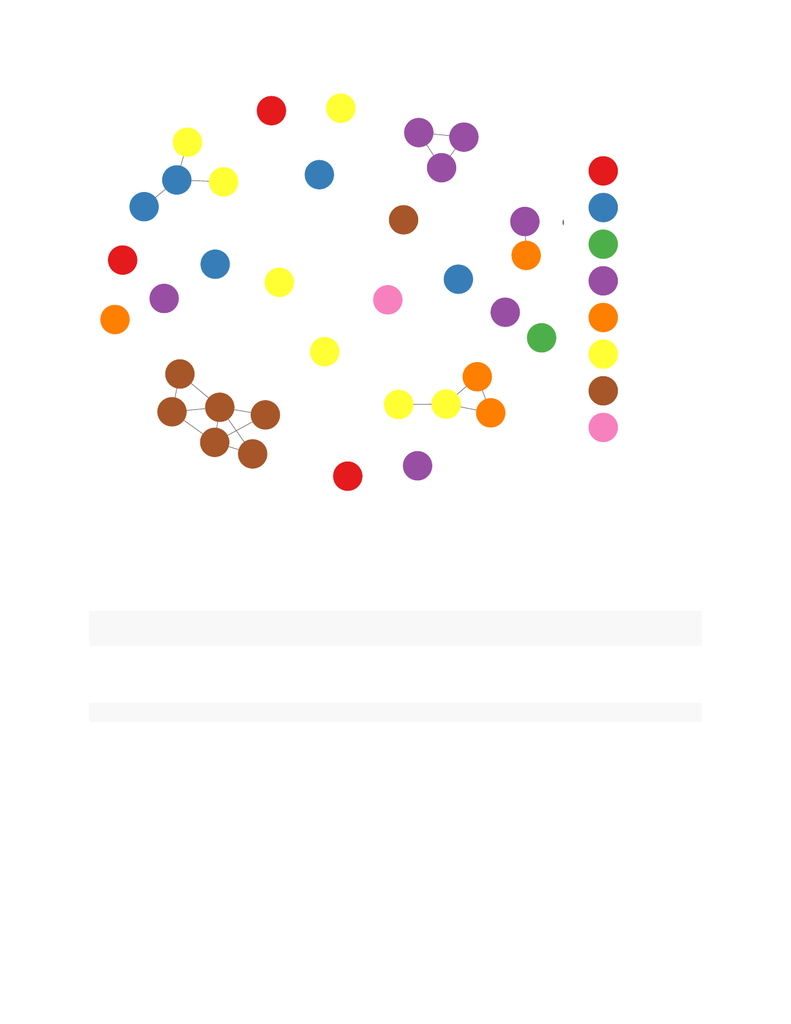

Superman

Mean Streets

Star Trek: The Motion Picture

Apocalypse Now

A Bridge Too Far

The Wiz

Close Encounters of the Third Kind

Jaws 2

Halloween

Halloween

The Godfather: Part II

The Exorcist

Jaws

Star Wars: Episode IV − A New Hope

The Texas Chain Saw Massacre

Fiddler on the Roof

The Rose

Escape from Alcatraz

The Godfather

Logan's Run

Grease

The Sting

One Flew Over the Cuckoo's Nest

Annie Hall

Animal House

Young Frankenstein

Blazing Saddles

Rocky

American Graffiti

Benji

Kingdom of the Spiders

Halloween

Sweet Sweetback's Baadasssss Song

The Texas Chain Saw Massacre

Pink Flamingos

Action

Adventure

Biography

Comedy

Crime

Drama

Horror

Musical

Movies from Prior to 1975

From this graph we see there are far fewer connections, and it appears movies that are released at the same

time are more likely to be related, as are sequels.

mydata3 = filter(imdb, year > 1900, year < 1975, country == "USA")

dim(mydata3)

## [1] 45 12

make_network(mydata3, cur_size = 9)

7

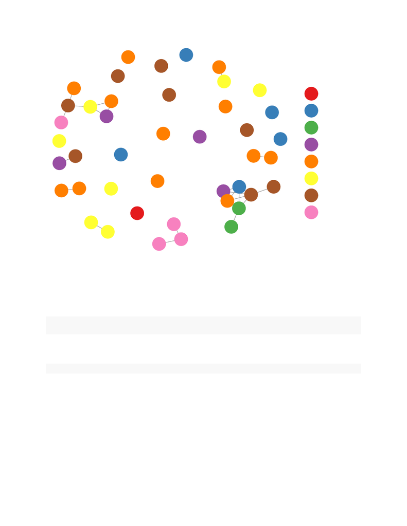

Pinocchio

Mean Streets

Darling Lili

Psycho

The Greatest Story Ever Told

My Fair Lady

The Godfather: Part II

The Exorcist

Doctor Zhivago

It's a Mad, Mad, Mad, Mad World

The Texas Chain Saw Massacre

Fiddler on the Roof

The Sound of Music

The Godfather

Butch Cassidy and the Sundance Kid

Mary Poppins

West Side Story

Duel in the Sun

The Sting

The Robe

The Greatest Show on Earth

Gone with the Wind

Major Dundee

Annie Get Your Gun

The Pirate

Some Like It Hot

The Wizard of Oz

Young Frankenstein

Blazing Saddles

The Best Years of Our Lives

The Lady from Shanghai

Modern Times

Snow White and the Seven Dwarfs

Beyond the Valley of the Dolls

On the Waterfront

American Graffiti

Top Hat

Benji

42nd Street

The Beast from 20,000 Fathoms

Sweet Sweetback's Baadasssss Song

The Texas Chain Saw Massacre

Pink Flamingos

Action

Adventure

Animation

Biography

Comedy

Crime

Drama

Horror

Here there are too many movies to be able to read each title, so I just remove it.

Does it look like movies are generally grouped by genre?

mydata4 = filter(imdb, year > 2005, year < 2008, country == "USA")

dim(mydata4)

## [1] 253 12

make_network(mydata4, cur_size = 3, add.label = F)

8

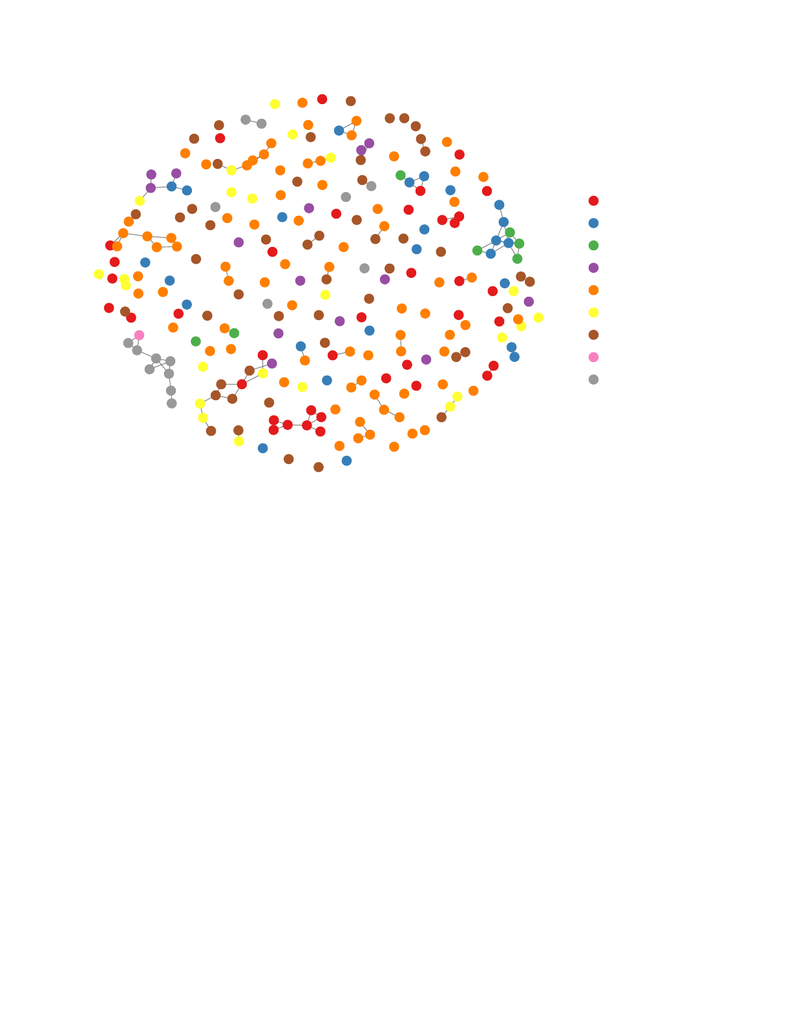

Action

Adventure

Animation

Biography

Comedy

Crime

Drama

Fantasy

Horror

9